# 2. Land-cover change analysis with TWDTW

Victor Maus

This vignette provides a short guide on how to perform a Time-Weighted Dynamic Time Warping (TWDTW) analysis on raster image time series using `dtwSat`. For more details about TWDTW read Maus et al. (2016) and Maus et al. (2019).

# Create multi-band image time series

`dtwSat` provides a set of images extracted from `MOD13Q1` dataset for a region within the Brazilian Amazon. You can load these images with

```r
library(dtwSat)

evi  <- brick(system.file("lucc_MT/data/evi.tif",  package = "dtwSat"))
ndvi <- brick(system.file("lucc_MT/data/ndvi.tif", package = "dtwSat"))
red  <- brick(system.file("lucc_MT/data/red.tif",  package = "dtwSat"))
blue <- brick(system.file("lucc_MT/data/blue.tif", package = "dtwSat"))
nir  <- brick(system.file("lucc_MT/data/nir.tif",  package = "dtwSat"))
mir  <- brick(system.file("lucc_MT/data/mir.tif",  package = "dtwSat"))
doy  <- brick(system.file("lucc_MT/data/doy.tif",  package = "dtwSat"))
```

The `tif` files above have been pre-processed, so that a single file has the complete time series for each band. One can also built the time series for each band from independent files using the function `stack` from the R package `raster`.

Note that every band must have the same extend, resolution, and number of images, i.e. the same number of observations across space and time. To create the multi-band image time series we need the dates of each observation, which for the set of images above are

```r
timeline <- scan(system.file("lucc_MT/data/timeline", package = "dtwSat"), what="date")
timeline
```

```
##   [1] "2007-09-14" "2007-09-30" "2007-10-16" "2007-11-01" "2007-11-17"
##   [6] "2007-12-03" "2007-12-19" "2008-01-01" "2008-01-17" "2008-02-02"
##  [11] "2008-02-18" "2008-03-05" "2008-03-21" "2008-04-06" "2008-04-22"
##  [16] "2008-05-08" "2008-05-24" "2008-06-09" "2008-06-25" "2008-07-11"
##  [21] "2008-07-27" "2008-08-12" "2008-08-28" "2008-09-13" "2008-09-29"
##  [26] "2008-10-15" "2008-10-31" "2008-11-16" "2008-12-02" "2008-12-18"
##  [31] "2009-01-01" "2009-01-17" "2009-02-02" "2009-02-18" "2009-03-06"
##  [36] "2009-03-22" "2009-04-07" "2009-04-23" "2009-05-09" "2009-05-25"
##  [41] "2009-06-10" "2009-06-26" "2009-07-12" "2009-07-28" "2009-08-13"
##  [46] "2009-08-29" "2009-09-14" "2009-09-30" "2009-10-16" "2009-11-01"
##  [51] "2009-11-17" "2009-12-03" "2009-12-19" "2010-01-01" "2010-01-17"
##  [56] "2010-02-02" "2010-02-18" "2010-03-06" "2010-03-22" "2010-04-07"
##  [61] "2010-04-23" "2010-05-09" "2010-05-25" "2010-06-10" "2010-06-26"
##  [66] "2010-07-12" "2010-07-28" "2010-08-13" "2010-08-29" "2010-09-14"
##  [71] "2010-09-30" "2010-10-16" "2010-11-01" "2010-11-17" "2010-12-03"
##  [76] "2010-12-19" "2011-01-01" "2011-01-17" "2011-02-02" "2011-02-18"
##  [81] "2011-03-06" "2011-03-22" "2011-04-07" "2011-04-23" "2011-05-09"
##  [86] "2011-05-25" "2011-06-10" "2011-06-26" "2011-07-12" "2011-07-28"
##  [91] "2011-08-13" "2011-08-29" "2011-09-14" "2011-09-30" "2011-10-16"
##  [96] "2011-11-01" "2011-11-17" "2011-12-03" "2011-12-19" "2012-01-01"
## [101] "2012-01-17" "2012-02-02" "2012-02-18" "2012-03-05" "2012-03-21"
## [106] "2012-04-06" "2012-04-22" "2012-05-08" "2012-05-24" "2012-06-09"
## [111] "2012-06-25" "2012-07-11" "2012-07-27" "2012-08-12" "2012-08-28"
## [116] "2012-09-13" "2012-09-29" "2012-10-15" "2012-10-31" "2012-11-16"
## [121] "2012-12-02" "2012-12-18" "2013-01-01" "2013-01-17" "2013-02-02"
## [126] "2013-02-18" "2013-03-06" "2013-03-22" "2013-04-07" "2013-04-23"
## [131] "2013-05-09" "2013-05-25" "2013-06-10" "2013-06-26" "2013-07-12"
## [136] "2013-08-13" "2013-08-29"
```

Finally, we can create the multi-band image time series with

```r
rts <- twdtwRaster(evi, ndvi, red, blue, nir, mir, timeline = timeline, doy = doy)
rts
## An object of class "twdtwRaster"
## Time series layers: doy evi ndvi red blue nir mir
## Time range: 2007-09-14 ... 2013-08-29
## Dimensions: 7 27 37 137 (nlayers, nrow, ncol, length)
## Resolution: 231.6564 231.6564  (x, y)
## Extent    : -6089551 -6080979 -1339205 -1332951 (xmin, xmax, ymin, ymax)
## Coord.ref.: +proj=sinu +lon_0=0 +x_0=0 +y_0=0 +R=6371007.181 +units=m +no_defs
```

The multi-band image time series has 7 bands and 137 observations ranging from 2007-09-14 to 2013-08-29.

# Create a library of vegetation profiles

To crate a library of profiles we need a set of samples. `dtwSat` provides a set of samples of land cover classes for the study area. We can load the samples with

```r
field_samples <- read.csv(system.file("lucc_MT/data/samples.csv", package = "dtwSat"))
head(field_samples)
```

```
##   longitude  latitude       from         to         label
## 1 -55.98819 -12.03646 2011-09-01 2012-09-01 Cotton-fallow
## 2 -55.99118 -12.04062 2011-09-01 2012-09-01 Cotton-fallow
## 3 -55.98606 -12.03646 2011-09-01 2012-09-01 Cotton-fallow
## 4 -55.98562 -12.03437 2011-09-01 2012-09-01 Cotton-fallow
## 5 -55.98475 -12.03021 2011-09-01 2012-09-01 Cotton-fallow
## 6 -55.98393 -12.03646 2011-09-01 2012-09-01 Cotton-fallow
```

We split this samples into a training and a validation set, such that

```r
library(caret)

set.seed(1) # set for reproducibility

I <- unlist(createDataPartition(field_samples$label, p = 0.1))

training_samples <- field_samples[I,]

validation_samples <- field_samples[-I,]
```

To get the time series for each sample in the training set, we can run

```r
training_ts <- getTimeSeries(rts,
                             y = training_samples,
                             proj4string = "+proj=longlat +datum=WGS84 +no_defs +ellps=WGS84 +towgs84=0,0,0")
```

Finally, we can use the training samples to crate the profiles library with

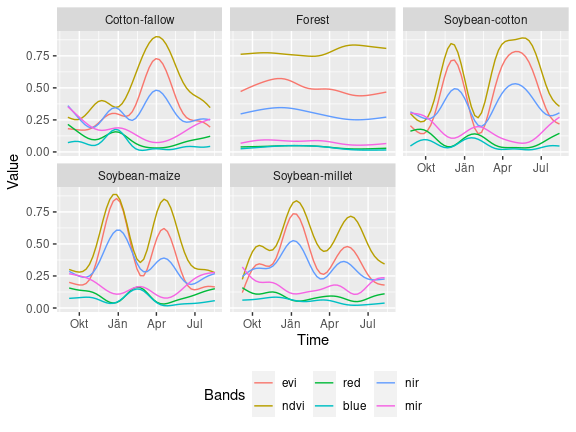

```r
profiles_library <- createPatterns(training_ts,
                                   freq = 8,
                                   formula = y ~ s(x))

plot(profiles_library, type = "patterns")
```

The function `createPatterns` using generalized additive models (GAMs) to create the profiles. For details see `?gam` from `mgcv` package.

# Classify image time series

```r
system.time(
  twdtw_lucc <- twdtwApply(x = rts,
                           y = profiles_library,
                           alpha = -0.1,
                           beta = 50,
                           progress = 'text',
                           minrows = 30,
                           legacy = FALSE,
                           time.window = TRUE)
)
  |
  |                                                                      |   0%
```

```
##    user  system elapsed
##   7.061   0.020   7.084
```

Note the argument `legacy = FALSE`. Setting this argument to `FALSE` considerably improves the performance of the processing as it does not keep any intermediate dataset. Using `time.window = TRUE` implements a change in the TWDTW algorithm to reduce processing.

One can also run TWDTW in parallel. For a small area, the performance is not much better than the sequential processing. However, for larger areas, the parallel processing can reduce processing time. To run `twdtwApply` in parallel setup and register a cluster before calling the function, such that

```r
library(doParallel)
library(parallel)
library(foreach)

cl <- makeCluster(detectCores(), type = "FORK")
registerDoParallel(cl)

system.time(
  twdtw_lucc <- twdtwApply(x = rts,
                           y = profiles_library,
                           alpha = -0.1,
                           beta = 50,
                           progress = 'text',
                           minrows = 30,
                           legacy = FALSE,
                           time.window = TRUE)
)

registerDoSEQ()
stopCluster(cl)
```

# Assess classifiaction results

`dtwSat` provides a set of functions to asses the classification results. For example with

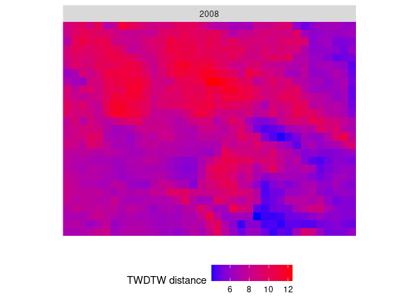

```r
# Plot TWDTW distances for the first year
  plot(twdtw_lucc, type = "distance", time.levels = 1)
```

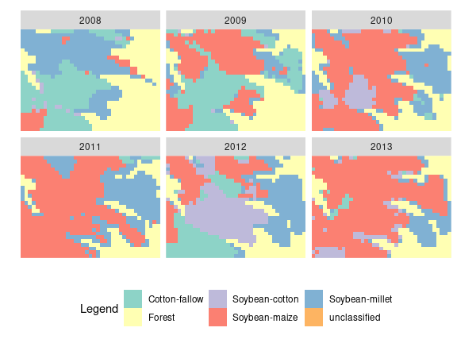

```r
# Plot TWDTW classification results
  plot(twdtw_lucc, type = "map")
```

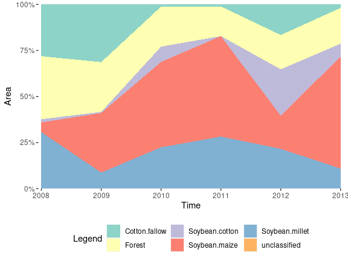

```r
# Plot mapped area time series
  plot(twdtw_lucc, type = "area")
```

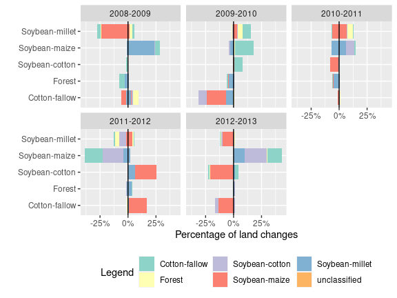

```r
# Plot land-cover changes
  plot(twdtw_lucc, type = "changes")
```

The package also offers a set of methods to assess the classification accuracy and visualize the results.

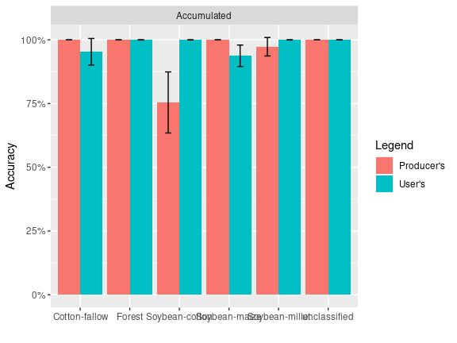

```r
# Assess classification
  twdtw_assess <-
    twdtwAssess(twdtw_lucc,
                y = validation_samples,
                proj4string = "+proj=longlat +datum=WGS84 +no_defs +ellps=WGS84 +towgs84=0,0,0",
                conf.int = .95)

# Plot map accuracy
  plot(twdtw_assess, type = "accuracy")
```

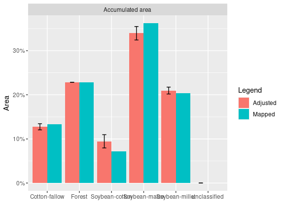

```r
# Plot area uncertainty
  plot(twdtw_assess, type = "area")
```

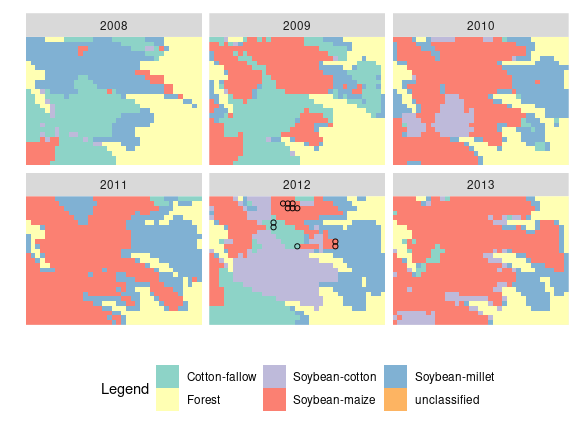

```r
# Plot misclassified samples
  plot(twdtw_assess, type = "map", samples = "incorrect")
```

```r
# Get latex table with error matrix
  twdtwXtable(twdtw_assess, table.type = "matrix")
## % latex table generated in R 4.2.1 by xtable 1.8-4 package
## % Tue Oct 11 17:31:08 2022
## \begin{table}[ht]
## \centering
## \begin{tabular}{rrrrrrrrrr}
##   \hline
##   &\multicolumn{6}{c}{Reference class}&&\\
## \multicolumn{1}{c}{Map class} & Cotton-fallow & Forest & Soybean-cotton & Soybean-maize & Soybean-millet & unclassified & Total & Area & w\\
##  \hline
## Cotton-fallow & 61 & 0 & 3 & 0 & 0 & 0 & 64 & 43039064.00 & 0.134 \\
##   Forest & 0 & 124 & 0 & 0 & 0 & 0 & 124 & 73520595.60 & 0.229 \\
##   Soybean-cotton & 0 & 0 & 62 & 0 & 0 & 0 & 62 & 22968478.04 & 0.071 \\
##   Soybean-maize & 0 & 0 & 6 & 120 & 2 & 0 & 128 & 116505994.93 & 0.362 \\
##   Soybean-millet & 0 & 0 & 0 & 0 & 163 & 0 & 163 & 65631889.36 & 0.204 \\
##   unclassified & 0 & 0 & 0 & 0 & 0 & 0 & 0 & 0.00 & 0.000 \\
##   Total & 61 & 124 & 71 & 120 & 165 & 0 & 541 & 321666021.93 & 1.000 \\
##    \hline
## \end{tabular}
## \end{table}

# Get latex table with error accuracy
  twdtwXtable(twdtw_assess, table.type = "accuracy")
## % latex table generated in R 4.2.1 by xtable 1.8-4 package
## % Tue Oct 11 17:31:08 2022
## \begin{table}[ht]
## \centering
## \begin{tabular}{rllllllllll}
##   \hline
##   &\multicolumn{6}{c}{Reference class}&&&&\\
## \multicolumn{1}{c}{Map class} & Cotton-fallow & Forest & Soybean-cotton & Soybean-maize & Soybean-millet & unclassified & Total & User's* & Producers's* & Overall*\\
##  \hline
## Cotton-fallow & 0.13 & 0.00 & 0.00 & 0.00 & 0.00 & 0.00 & 0.13 & 0.95$\pm$0.05 & 1.00$\pm$0.00 & 0.97$\pm$0.02 \\
##   Forest & 0.00 & 0.23 & 0.00 & 0.00 & 0.00 & 0.00 & 0.23 & 1.00$\pm$0.00 & 1.00$\pm$0.00 &  \\
##   Soybean-cotton & 0.01 & 0.00 & 0.07 & 0.02 & 0.00 & 0.00 & 0.09 & 1.00$\pm$0.00 & 0.75$\pm$0.12 &  \\
##   Soybean-maize & 0.00 & 0.00 & 0.00 & 0.34 & 0.00 & 0.00 & 0.34 & 0.94$\pm$0.04 & 1.00$\pm$0.00 &  \\
##   Soybean-millet & 0.00 & 0.00 & 0.00 & 0.01 & 0.20 & 0.00 & 0.21 & 1.00$\pm$0.00 & 0.97$\pm$0.04 &  \\
##   unclassified & 0.00 & 0.00 & 0.00 & 0.00 & 0.00 & 0.00 & 0.00 & 1.00$\pm$-0.00 & 1.00$\pm$0.00 &  \\
##   Total & 0.13 & 0.23 & 0.07 & 0.36 & 0.20 & 0.00 & 1.00 &  &  &  \\
##    \hline
## \multicolumn{10}{l}{* 95\% confidence interval.}
## \end{tabular}
## \end{table}

# Get latex table with area uncertainty
  twdtwXtable(twdtw_assess, table.type = "area")
## % latex table generated in R 4.2.1 by xtable 1.8-4 package
## % Tue Oct 11 17:31:08 2022
## \begin{table}[ht]
## \centering
## \begin{tabular}{rlll}
##   \hline
##   \multicolumn{1}{c}{Class} & Mapped area & Adjusted area & Margin of error*\\
##  \hline
## Cotton-fallow & 43039064.00 & 41021607.87 & $\pm$2246395.42 \\
##   Forest & 73520595.60 & 73520595.60 & $\pm$0.00 \\
##   Soybean-cotton & 22968478.04 & 30447152.68 & $\pm$4836290.48 \\
##   Soybean-maize & 116505994.93 & 109224370.25 & $\pm$4904786.98 \\
##   Soybean-millet & 65631889.36 & 67452295.53 & $\pm$2512955.54 \\
##   unclassified & 0.00 & 0.00 & $\pm$0.00 \\
##    \hline
## \multicolumn{3}{l}{* 95\% confidence interval.}
## \end{tabular}
## \end{table}
```

This short introduction showed how to use `dtwSat` for land-cover change analyse. To learn TWDTW read Maus et al. (2016) and Maus et al. (2019).

# References

Maus, Victor, Gilberto Camara, Marius Appel, and Edzer Pebesma. 2019. “dtwSat: Time-Weighted Dynamic Time Warping for Satellite Image Time Series Analysis in R.” *Journal of Statistical Software* 88 (5): 1–31. https://doi.org/10.18637/jss.v088.i05.

Maus, Victor, Gilberto Camara, Ricardo Cartaxo, Alber Sanchez, Fernando M. Ramos, and Gilberto R. de Queiroz. 2016. “A Time-Weighted Dynamic Time Warping Method for Land-Use and Land-Cover Mapping.” *IEEE Journal of Selected Topics in Applied Earth Observations and Remote Sensing* 9 (8): 3729–39. https://doi.org/10.1109/JSTARS.2016.2517118.